{% raw %}

{% endraw %} {% raw %}

{% endraw %} {% raw %}

```python
import matplotlib.pyplot as plt
from matplotlib import rcParams
plt.rcParams['font.family'] = 'serif'
FONTSIZE = 22
```

{% endraw %}

> GEFCom2014 meta inforamtion

{% raw %}

`class` `Extended`[[source]](https://github.com/Nixtla/neuralforecast/tree/main/neuralforecast/data/datasets/gefcom2014.py#L40)

> `Extended`(**`test_date`**:`str`=*`'2016-12-27'`*, **`name`**:`str`=*`'Extended'`*, **`freq`**:`str`=*`'Y'`*)

Extended(test_date: str = '2016-12-27', name: str = 'Extended', freq: str = 'Y')

{% endraw %} {% raw %}

`class` `Load`[[source]](https://github.com/Nixtla/neuralforecast/tree/main/neuralforecast/data/datasets/gefcom2014.py#L46)

> `Load`(**`test_date`**:`str`=*`'2016-12-27'`*, **`name`**:`str`=*`'Load'`*, **`freq`**:`str`=*`'H'`*)

Load(test_date: str = '2016-12-27', name: str = 'Load', freq: str = 'H')

{% endraw %} {% raw %}

`class` `Price`[[source]](https://github.com/Nixtla/neuralforecast/tree/main/neuralforecast/data/datasets/gefcom2014.py#L52)

> `Price`(**`test_date`**:`str`=*`'2015-01-04'`*, **`name`**:`str`=*`'Price'`*, **`freq`**:`str`=*`'H'`*)

Price(test_date: str = '2015-01-04', name: str = 'Price', freq: str = 'H')

{% endraw %} {% raw %}

`class` `Solar`[[source]](https://github.com/Nixtla/neuralforecast/tree/main/neuralforecast/data/datasets/gefcom2014.py#L58)

> `Solar`(**`test_date`**:`str`=*`'2015-01-04'`*, **`name`**:`str`=*`'Solar'`*, **`freq`**:`str`=*`'H'`*)

Solar(test_date: str = '2015-01-04', name: str = 'Solar', freq: str = 'H')

{% endraw %} {% raw %}

`class` `Wind`[[source]](https://github.com/Nixtla/neuralforecast/tree/main/neuralforecast/data/datasets/gefcom2014.py#L64)

> `Wind`(**`test_date`**:`str`=*`'2016-01-04'`*, **`name`**:`str`=*`'Wind'`*, **`freq`**:`str`=*`'H'`*)

Wind(test_date: str = '2016-01-04', name: str = 'Wind', freq: str = 'H')

{% endraw %} {% raw %}

{% endraw %} {% raw %}

`class` `GEFCom2014`[[source]](https://github.com/Nixtla/neuralforecast/tree/main/neuralforecast/data/datasets/gefcom2014.py#L73)

> `GEFCom2014`()

{% endraw %} {% raw %}

{% endraw %} {% raw %}

```python
GEFCom2014.download(f'data')
```

```
INFO:nixtla.data.datasets.utils:Successfully downloaded GEFCom2014.zip?dl=1, 126360077, bytes.
INFO:nixtla.data.datasets.utils:Successfully decompressed data/gefcom2014/GEFCom2014.zip?dl=1
INFO:__main__:Successfully decompressed data/gefcom2014/GEFCom2014 Data/GEFCom2014-E_V2.zip
INFO:__main__:Successfully decompressed data/gefcom2014/GEFCom2014 Data/GEFCom2014-L_V2.zip
INFO:__main__:Successfully decompressed data/gefcom2014/GEFCom2014 Data/GEFCom2014-P_V2.zip
INFO:__main__:Successfully decompressed data/gefcom2014/GEFCom2014 Data/GEFCom2014-S_V2.zip
INFO:__main__:Successfully decompressed data/gefcom2014/GEFCom2014 Data/GEFCom2014-W_V2.zip
```

{% endraw %}

# GEFCom2014-L: Original Electricity Load Task Datasets

> GEFCom2014-L meta information

{% raw %}

`class` `LoadTask1`[[source]](https://github.com/Nixtla/neuralforecast/tree/main/neuralforecast/data/datasets/gefcom2014.py#L141)

> `LoadTask1`(**`test_start`**:`str`=*`'10/01/2010'`*, **`test_end`**:`str`=*`'11/01/2010'`*)

LoadTask1(test_start: str = '10/01/2010', test_end: str = '11/01/2010')

{% endraw %} {% raw %}

`class` `LoadTask2`[[source]](https://github.com/Nixtla/neuralforecast/tree/main/neuralforecast/data/datasets/gefcom2014.py#L146)

> `LoadTask2`(**`test_start`**:`str`=*`'11/01/2010'`*, **`test_end`**:`str`=*`'12/01/2010'`*)

LoadTask2(test_start: str = '11/01/2010', test_end: str = '12/01/2010')

{% endraw %} {% raw %}

`class` `LoadTask3`[[source]](https://github.com/Nixtla/neuralforecast/tree/main/neuralforecast/data/datasets/gefcom2014.py#L151)

> `LoadTask3`(**`test_start`**:`str`=*`'12/01/2010'`*, **`test_end`**:`str`=*`'01/01/2011'`*)

LoadTask3(test_start: str = '12/01/2010', test_end: str = '01/01/2011')

{% endraw %} {% raw %}

`class` `LoadTask4`[[source]](https://github.com/Nixtla/neuralforecast/tree/main/neuralforecast/data/datasets/gefcom2014.py#L156)

> `LoadTask4`(**`test_start`**:`str`=*`'01/01/2011'`*, **`test_end`**:`str`=*`'02/01/2011'`*)

LoadTask4(test_start: str = '01/01/2011', test_end: str = '02/01/2011')

{% endraw %} {% raw %}

`class` `LoadTask5`[[source]](https://github.com/Nixtla/neuralforecast/tree/main/neuralforecast/data/datasets/gefcom2014.py#L161)

> `LoadTask5`(**`test_start`**:`str`=*`'02/01/2011'`*, **`test_end`**:`str`=*`'03/01/2011'`*)

LoadTask5(test_start: str = '02/01/2011', test_end: str = '03/01/2011')

{% endraw %} {% raw %}

`class` `LoadTask6`[[source]](https://github.com/Nixtla/neuralforecast/tree/main/neuralforecast/data/datasets/gefcom2014.py#L166)

> `LoadTask6`(**`test_start`**:`str`=*`'03/01/2011'`*, **`test_end`**:`str`=*`'04/01/2011'`*)

LoadTask6(test_start: str = '03/01/2011', test_end: str = '04/01/2011')

{% endraw %} {% raw %}

`class` `LoadTask7`[[source]](https://github.com/Nixtla/neuralforecast/tree/main/neuralforecast/data/datasets/gefcom2014.py#L171)

> `LoadTask7`(**`test_start`**:`str`=*`'04/01/2011'`*, **`test_end`**:`str`=*`'05/01/2011'`*)

LoadTask7(test_start: str = '04/01/2011', test_end: str = '05/01/2011')

{% endraw %} {% raw %}

`class` `LoadTask8`[[source]](https://github.com/Nixtla/neuralforecast/tree/main/neuralforecast/data/datasets/gefcom2014.py#L176)

> `LoadTask8`(**`test_start`**:`str`=*`'05/01/2011'`*, **`test_end`**:`str`=*`'06/01/2011'`*)

LoadTask8(test_start: str = '05/01/2011', test_end: str = '06/01/2011')

{% endraw %} {% raw %}

`class` `LoadTask9`[[source]](https://github.com/Nixtla/neuralforecast/tree/main/neuralforecast/data/datasets/gefcom2014.py#L181)

> `LoadTask9`(**`test_start`**:`str`=*`'06/01/2011'`*, **`test_end`**:`str`=*`'07/01/2011'`*)

LoadTask9(test_start: str = '06/01/2011', test_end: str = '07/01/2011')

{% endraw %} {% raw %}

`class` `LoadTask10`[[source]](https://github.com/Nixtla/neuralforecast/tree/main/neuralforecast/data/datasets/gefcom2014.py#L186)

> `LoadTask10`(**`test_start`**:`str`=*`'07/01/2011'`*, **`test_end`**:`str`=*`'08/01/2011'`*)

LoadTask10(test_start: str = '07/01/2011', test_end: str = '08/01/2011')

{% endraw %} {% raw %}

`class` `LoadTask11`[[source]](https://github.com/Nixtla/neuralforecast/tree/main/neuralforecast/data/datasets/gefcom2014.py#L191)

> `LoadTask11`(**`test_start`**:`str`=*`'08/01/2011'`*, **`test_end`**:`str`=*`'09/01/2011'`*)

LoadTask11(test_start: str = '08/01/2011', test_end: str = '09/01/2011')

{% endraw %} {% raw %}

`class` `LoadTask12`[[source]](https://github.com/Nixtla/neuralforecast/tree/main/neuralforecast/data/datasets/gefcom2014.py#L196)

> `LoadTask12`(**`test_start`**:`str`=*`'09/01/2011'`*, **`test_end`**:`str`=*`'10/01/2011'`*)

LoadTask12(test_start: str = '09/01/2011', test_end: str = '10/01/2011')

{% endraw %} {% raw %}

`class` `LoadTask13`[[source]](https://github.com/Nixtla/neuralforecast/tree/main/neuralforecast/data/datasets/gefcom2014.py#L201)

> `LoadTask13`(**`test_start`**:`str`=*`'10/01/2011'`*, **`test_end`**:`str`=*`'11/01/2011'`*)

LoadTask13(test_start: str = '10/01/2011', test_end: str = '11/01/2011')

{% endraw %} {% raw %}

`class` `LoadTask14`[[source]](https://github.com/Nixtla/neuralforecast/tree/main/neuralforecast/data/datasets/gefcom2014.py#L206)

> `LoadTask14`(**`test_start`**:`str`=*`'11/01/2011'`*, **`test_end`**:`str`=*`'12/01/2011'`*)

LoadTask14(test_start: str = '11/01/2011', test_end: str = '12/01/2011')

{% endraw %} {% raw %}

`class` `LoadTask15`[[source]](https://github.com/Nixtla/neuralforecast/tree/main/neuralforecast/data/datasets/gefcom2014.py#L211)

> `LoadTask15`(**`test_start`**:`str`=*`'12/01/2011'`*, **`test_end`**:`str`=*`'01/01/2012'`*)

LoadTask15(test_start: str = '12/01/2011', test_end: str = '01/01/2012')

{% endraw %} {% raw %}

`class` `LoadTask16`[[source]](https://github.com/Nixtla/neuralforecast/tree/main/neuralforecast/data/datasets/gefcom2014.py#L216)

> `LoadTask16`(**`test_start`**:`str`=*`'01/01/2012'`*, **`test_end`**:`str`=*`'02/01/2012'`*)

LoadTask16(test_start: str = '01/01/2012', test_end: str = '02/01/2012')

{% endraw %} {% raw %}

{% endraw %} {% raw %}

`class` `GEFCom2014_L`[[source]](https://github.com/Nixtla/neuralforecast/tree/main/neuralforecast/data/datasets/gefcom2014.py#L230)

> `GEFCom2014_L`()

{% endraw %} {% raw %}

{% endraw %} {% raw %}

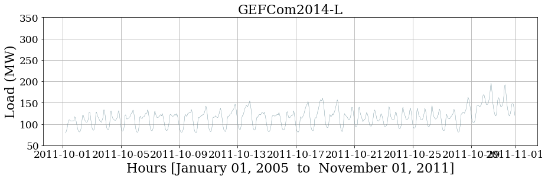

```python
Y_df, X_df, benchmark_df = GEFCom2014_L.load(directory='data', group='Task 14')

#ds = Y_df.ds.values[365*24:]
#y_true = Y_df.y.values[365*24:]
ds = Y_df.ds.values[-740:]
y_true = Y_df.y.values[-740:]

x_plot = Y_df.ds.values
x_plot_min = pd.to_datetime(x_plot.min()).strftime('%B %d, %Y')
x_plot_max = pd.to_datetime(x_plot.max()).strftime('%B %d, %Y')
x_axis_str = f'Hours [{x_plot_min}  to  {x_plot_max}]'
y_axis_str = 'Load (MW)'

fig = plt.figure(figsize=(15, 4))
fig.tight_layout()
ax0 = plt.subplot2grid((1,1),(0, 0))
axs = [ax0]

axs[0].plot(ds, y_true, color='#628793', linewidth=0.4, label='true')
axs[0].tick_params(labelsize=FONTSIZE-5)
axs[0].set_xlabel(x_axis_str, fontsize=FONTSIZE)
axs[0].set_ylabel(y_axis_str, fontsize=FONTSIZE)
plt.ylim(50, 350)
plt.title('GEFCom2014-L', fontsize=FONTSIZE)
plt.grid()
plt.show()
```

{% endraw %}

# GEFCom2014-E: Extended 2015 Electricity Load Task Datasets

{% raw %}

`class` `GEFCom2014_E`[[source]](https://github.com/Nixtla/neuralforecast/tree/main/neuralforecast/data/datasets/gefcom2014.py#L364)

> `GEFCom2014_E`()

{% endraw %} {% raw %}

{% endraw %} {% raw %}

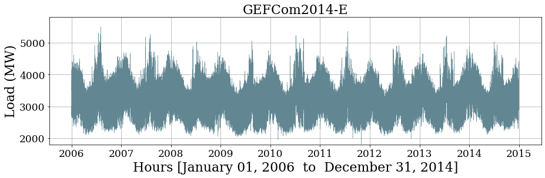

```python
Y_df, X_df = GEFCom2014_E.load(directory='data')

ds = Y_df.ds.values
y_true = Y_df.y.values

x_plot = Y_df.ds.values
x_plot_min = pd.to_datetime(x_plot.min()).strftime('%B %d, %Y')
x_plot_max = pd.to_datetime(x_plot.max()).strftime('%B %d, %Y')
x_axis_str = f'Hours [{x_plot_min}  to  {x_plot_max}]'
y_axis_str = 'Load (MW)'

fig = plt.figure(figsize=(15, 4))
fig.tight_layout()
ax0 = plt.subplot2grid((1,1),(0, 0))
axs = [ax0]

axs[0].plot(ds, y_true, color='#628793', linewidth=0.4, label='true')
axs[0].tick_params(labelsize=FONTSIZE-5)
axs[0].set_xlabel(x_axis_str, fontsize=FONTSIZE)
axs[0].set_ylabel(y_axis_str, fontsize=FONTSIZE)
plt.ylim(1800, 5800)
plt.title('GEFCom2014-E', fontsize=FONTSIZE)
plt.grid()
plt.show()
```

{% endraw %}

# GEFCOM2014-P: Electricity Price Task Datasets

- Y: Hourly electricity price
- X: Zonal and system load day-ahead forecasts
- Tasks: Fifteen one-day-ahead forecast quantiles of hourly price on rolling basis.

> GEFcom2014-P meta information

{% raw %}

`class` `PriceTask1`[[source]](https://github.com/Nixtla/neuralforecast/tree/main/neuralforecast/data/datasets/gefcom2014.py#L405)

> `PriceTask1`(**`test_start`**:`str`=*`'06/16/2013'`*, **`test_end`**:`str`=*`'06/17/2013'`*)

PriceTask1(test_start: str = '06/16/2013', test_end: str = '06/17/2013')

{% endraw %} {% raw %}

`class` `PriceTask2`[[source]](https://github.com/Nixtla/neuralforecast/tree/main/neuralforecast/data/datasets/gefcom2014.py#L410)

> `PriceTask2`(**`test_start`**:`str`=*`'06/17/2013'`*, **`test_end`**:`str`=*`'06/18/2013'`*)

PriceTask2(test_start: str = '06/17/2013', test_end: str = '06/18/2013')

{% endraw %} {% raw %}

`class` `PriceTask3`[[source]](https://github.com/Nixtla/neuralforecast/tree/main/neuralforecast/data/datasets/gefcom2014.py#L415)

> `PriceTask3`(**`test_start`**:`str`=*`'06/24/2013'`*, **`test_end`**:`str`=*`'06/25/2013'`*)

PriceTask3(test_start: str = '06/24/2013', test_end: str = '06/25/2013')

{% endraw %} {% raw %}

`class` `PriceTask4`[[source]](https://github.com/Nixtla/neuralforecast/tree/main/neuralforecast/data/datasets/gefcom2014.py#L420)

> `PriceTask4`(**`test_start`**:`str`=*`'07/04/2013'`*, **`test_end`**:`str`=*`'07/05/2013'`*)

PriceTask4(test_start: str = '07/04/2013', test_end: str = '07/05/2013')

{% endraw %} {% raw %}

`class` `PriceTask5`[[source]](https://github.com/Nixtla/neuralforecast/tree/main/neuralforecast/data/datasets/gefcom2014.py#L425)

> `PriceTask5`(**`test_start`**:`str`=*`'07/09/2013'`*, **`test_end`**:`str`=*`'07/10/2013'`*)

PriceTask5(test_start: str = '07/09/2013', test_end: str = '07/10/2013')

{% endraw %} {% raw %}

`class` `PriceTask6`[[source]](https://github.com/Nixtla/neuralforecast/tree/main/neuralforecast/data/datasets/gefcom2014.py#L430)

> `PriceTask6`(**`test_start`**:`str`=*`'07/13/2013'`*, **`test_end`**:`str`=*`'07/14/2013'`*)

PriceTask6(test_start: str = '07/13/2013', test_end: str = '07/14/2013')

{% endraw %} {% raw %}

`class` `PriceTask7`[[source]](https://github.com/Nixtla/neuralforecast/tree/main/neuralforecast/data/datasets/gefcom2014.py#L435)

> `PriceTask7`(**`test_start`**:`str`=*`'07/16/2013'`*, **`test_end`**:`str`=*`'07/17/2013'`*)

PriceTask7(test_start: str = '07/16/2013', test_end: str = '07/17/2013')

{% endraw %} {% raw %}

`class` `PriceTask8`[[source]](https://github.com/Nixtla/neuralforecast/tree/main/neuralforecast/data/datasets/gefcom2014.py#L440)

> `PriceTask8`(**`test_start`**:`str`=*`'07/18/2013'`*, **`test_end`**:`str`=*`'07/19/2013'`*)

PriceTask8(test_start: str = '07/18/2013', test_end: str = '07/19/2013')

{% endraw %} {% raw %}

`class` `PriceTask9`[[source]](https://github.com/Nixtla/neuralforecast/tree/main/neuralforecast/data/datasets/gefcom2014.py#L445)

> `PriceTask9`(**`test_start`**:`str`=*`'07/19/2013'`*, **`test_end`**:`str`=*`'07/20/2013'`*)

PriceTask9(test_start: str = '07/19/2013', test_end: str = '07/20/2013')

{% endraw %} {% raw %}

`class` `PriceTask10`[[source]](https://github.com/Nixtla/neuralforecast/tree/main/neuralforecast/data/datasets/gefcom2014.py#L450)

> `PriceTask10`(**`test_start`**:`str`=*`'07/20/2013'`*, **`test_end`**:`str`=*`'07/21/2013'`*)

PriceTask10(test_start: str = '07/20/2013', test_end: str = '07/21/2013')

{% endraw %} {% raw %}

`class` `PriceTask11`[[source]](https://github.com/Nixtla/neuralforecast/tree/main/neuralforecast/data/datasets/gefcom2014.py#L455)

> `PriceTask11`(**`test_start`**:`str`=*`'07/24/2013'`*, **`test_end`**:`str`=*`'07/25/2013'`*)

PriceTask11(test_start: str = '07/24/2013', test_end: str = '07/25/2013')

{% endraw %} {% raw %}

`class` `PriceTask12`[[source]](https://github.com/Nixtla/neuralforecast/tree/main/neuralforecast/data/datasets/gefcom2014.py#L460)

> `PriceTask12`(**`test_start`**:`str`=*`'07/25/2013'`*, **`test_end`**:`str`=*`'07/26/2013'`*)

PriceTask12(test_start: str = '07/25/2013', test_end: str = '07/26/2013')

{% endraw %} {% raw %}

`class` `PriceTask13`[[source]](https://github.com/Nixtla/neuralforecast/tree/main/neuralforecast/data/datasets/gefcom2014.py#L465)

> `PriceTask13`(**`test_start`**:`str`=*`'12/07/2013'`*, **`test_end`**:`str`=*`'12/08/2013'`*)

PriceTask13(test_start: str = '12/07/2013', test_end: str = '12/08/2013')

{% endraw %} {% raw %}

`class` `PriceTask14`[[source]](https://github.com/Nixtla/neuralforecast/tree/main/neuralforecast/data/datasets/gefcom2014.py#L470)

> `PriceTask14`(**`test_start`**:`str`=*`'12/08/2013'`*, **`test_end`**:`str`=*`'12/09/2013'`*)

PriceTask14(test_start: str = '12/08/2013', test_end: str = '12/09/2013')

{% endraw %} {% raw %}

`class` `PriceTask15`[[source]](https://github.com/Nixtla/neuralforecast/tree/main/neuralforecast/data/datasets/gefcom2014.py#L475)

> `PriceTask15`(**`test_start`**:`str`=*`'12/17/2013'`*, **`test_end`**:`str`=*`'12/18/2013'`*)

PriceTask15(test_start: str = '12/17/2013', test_end: str = '12/18/2013')

{% endraw %} {% raw %}

{% endraw %} {% raw %}

`class` `GEFCom2014_P`[[source]](https://github.com/Nixtla/neuralforecast/tree/main/neuralforecast/data/datasets/gefcom2014.py#L489)

> `GEFCom2014_P`()

{% endraw %} {% raw %}

{% endraw %} {% raw %}

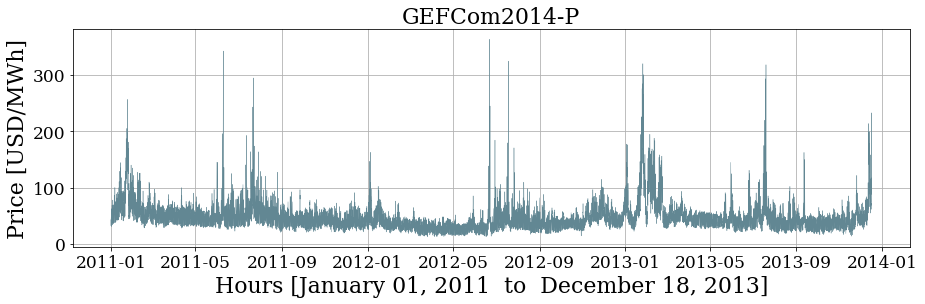

```python
Y_df, X_df, benchmark_df = GEFCom2014_P.load(directory='data', group='Task 15')

ds = Y_df.ds.values
y_true = Y_df.y.values

x_plot = Y_df.ds.values
x_plot_min = pd.to_datetime(x_plot.min()).strftime('%B %d, %Y')
x_plot_max = pd.to_datetime(x_plot.max()).strftime('%B %d, %Y')
x_axis_str = f'Hours [{x_plot_min}  to  {x_plot_max}]'
y_axis_str = 'Price [USD/MWh]'

fig = plt.figure(figsize=(15, 4))
fig.tight_layout()
ax0 = plt.subplot2grid((1,1),(0, 0))
axs = [ax0]

axs[0].plot(ds, y_true, color='#628793', linewidth=0.4, label='true')
axs[0].tick_params(labelsize=FONTSIZE-5)
axs[0].set_xlabel(x_axis_str, fontsize=FONTSIZE)
axs[0].set_ylabel(y_axis_str, fontsize=FONTSIZE)
plt.title('GEFCom2014-P', fontsize=FONTSIZE)
plt.grid()
plt.show()
```

{% endraw %}

# GEFCOM2014-W: Wind Power Generation Task Datasets

- Y: 10 target wind power series, for 10 different Australian wind farms.
- X: Wind forecasts at 10m and 100m height for the zonal (u) and meridional (v) wind components (winning submission used external data).
- Tasks: Fifteen one-month-ahead hourly wind power generation for 10 farms.

> GEFcom2014-W meta information

{% raw %}

`class` `WindTask1`[[source]](https://github.com/Nixtla/neuralforecast/tree/main/neuralforecast/data/datasets/gefcom2014.py#L607)

> `WindTask1`(**`test_start`**:`str`=*`'10/01/2012'`*, **`test_end`**:`str`=*`'11/01/2012'`*)

WindTask1(test_start: str = '10/01/2012', test_end: str = '11/01/2012')

{% endraw %} {% raw %}

`class` `WindTask2`[[source]](https://github.com/Nixtla/neuralforecast/tree/main/neuralforecast/data/datasets/gefcom2014.py#L612)

> `WindTask2`(**`test_start`**:`str`=*`'11/01/2012'`*, **`test_end`**:`str`=*`'12/01/2012'`*)

WindTask2(test_start: str = '11/01/2012', test_end: str = '12/01/2012')

{% endraw %} {% raw %}

`class` `WindTask3`[[source]](https://github.com/Nixtla/neuralforecast/tree/main/neuralforecast/data/datasets/gefcom2014.py#L617)

> `WindTask3`(**`test_start`**:`str`=*`'12/01/2012'`*, **`test_end`**:`str`=*`'01/01/2013'`*)

WindTask3(test_start: str = '12/01/2012', test_end: str = '01/01/2013')

{% endraw %} {% raw %}

`class` `WindTask4`[[source]](https://github.com/Nixtla/neuralforecast/tree/main/neuralforecast/data/datasets/gefcom2014.py#L622)

> `WindTask4`(**`test_start`**:`str`=*`'01/01/2013'`*, **`test_end`**:`str`=*`'02/01/2013'`*)

WindTask4(test_start: str = '01/01/2013', test_end: str = '02/01/2013')

{% endraw %} {% raw %}

`class` `WindTask5`[[source]](https://github.com/Nixtla/neuralforecast/tree/main/neuralforecast/data/datasets/gefcom2014.py#L627)

> `WindTask5`(**`test_start`**:`str`=*`'02/01/2013'`*, **`test_end`**:`str`=*`'03/01/2013'`*)

WindTask5(test_start: str = '02/01/2013', test_end: str = '03/01/2013')

{% endraw %} {% raw %}

`class` `WindTask6`[[source]](https://github.com/Nixtla/neuralforecast/tree/main/neuralforecast/data/datasets/gefcom2014.py#L632)

> `WindTask6`(**`test_start`**:`str`=*`'03/01/2013'`*, **`test_end`**:`str`=*`'04/01/2013'`*)

WindTask6(test_start: str = '03/01/2013', test_end: str = '04/01/2013')

{% endraw %} {% raw %}

`class` `WindTask7`[[source]](https://github.com/Nixtla/neuralforecast/tree/main/neuralforecast/data/datasets/gefcom2014.py#L637)

> `WindTask7`(**`test_start`**:`str`=*`'04/01/2013'`*, **`test_end`**:`str`=*`'05/01/2013'`*)

WindTask7(test_start: str = '04/01/2013', test_end: str = '05/01/2013')

{% endraw %} {% raw %}

`class` `WindTask8`[[source]](https://github.com/Nixtla/neuralforecast/tree/main/neuralforecast/data/datasets/gefcom2014.py#L642)

> `WindTask8`(**`test_start`**:`str`=*`'05/01/2013'`*, **`test_end`**:`str`=*`'06/01/2013'`*)

WindTask8(test_start: str = '05/01/2013', test_end: str = '06/01/2013')

{% endraw %} {% raw %}

`class` `WindTask9`[[source]](https://github.com/Nixtla/neuralforecast/tree/main/neuralforecast/data/datasets/gefcom2014.py#L647)

> `WindTask9`(**`test_start`**:`str`=*`'06/01/2013'`*, **`test_end`**:`str`=*`'07/01/2013'`*)

WindTask9(test_start: str = '06/01/2013', test_end: str = '07/01/2013')

{% endraw %} {% raw %}

`class` `WindTask10`[[source]](https://github.com/Nixtla/neuralforecast/tree/main/neuralforecast/data/datasets/gefcom2014.py#L652)

> `WindTask10`(**`test_start`**:`str`=*`'07/01/2013'`*, **`test_end`**:`str`=*`'08/01/2013'`*)

WindTask10(test_start: str = '07/01/2013', test_end: str = '08/01/2013')

{% endraw %} {% raw %}

`class` `WindTask11`[[source]](https://github.com/Nixtla/neuralforecast/tree/main/neuralforecast/data/datasets/gefcom2014.py#L657)

> `WindTask11`(**`test_start`**:`str`=*`'08/01/2013'`*, **`test_end`**:`str`=*`'09/01/2013'`*)

WindTask11(test_start: str = '08/01/2013', test_end: str = '09/01/2013')

{% endraw %} {% raw %}

`class` `WindTask12`[[source]](https://github.com/Nixtla/neuralforecast/tree/main/neuralforecast/data/datasets/gefcom2014.py#L662)

> `WindTask12`(**`test_start`**:`str`=*`'09/01/2013'`*, **`test_end`**:`str`=*`'10/01/2013'`*)

WindTask12(test_start: str = '09/01/2013', test_end: str = '10/01/2013')

{% endraw %} {% raw %}

`class` `WindTask13`[[source]](https://github.com/Nixtla/neuralforecast/tree/main/neuralforecast/data/datasets/gefcom2014.py#L667)

> `WindTask13`(**`test_start`**:`str`=*`'10/01/2013'`*, **`test_end`**:`str`=*`'11/01/2013'`*)

WindTask13(test_start: str = '10/01/2013', test_end: str = '11/01/2013')

{% endraw %} {% raw %}

`class` `WindTask14`[[source]](https://github.com/Nixtla/neuralforecast/tree/main/neuralforecast/data/datasets/gefcom2014.py#L672)

> `WindTask14`(**`test_start`**:`str`=*`'11/01/2013'`*, **`test_end`**:`str`=*`'12/01/2013'`*)

WindTask14(test_start: str = '11/01/2013', test_end: str = '12/01/2013')

{% endraw %} {% raw %}

`class` `WindTask15`[[source]](https://github.com/Nixtla/neuralforecast/tree/main/neuralforecast/data/datasets/gefcom2014.py#L677)

> `WindTask15`(**`test_start`**:`str`=*`'12/01/2013'`*, **`test_end`**:`str`=*`'01/01/2014'`*)

WindTask15(test_start: str = '12/01/2013', test_end: str = '01/01/2014')

{% endraw %} {% raw %}

{% endraw %} {% raw %}

`class` `GEFCom2014_W`[[source]](https://github.com/Nixtla/neuralforecast/tree/main/neuralforecast/data/datasets/gefcom2014.py#L691)

> `GEFCom2014_W`()

{% endraw %} {% raw %}

{% endraw %} {% raw %}

```
INFO:__main__:Successfully decompressed Wind tasks
```

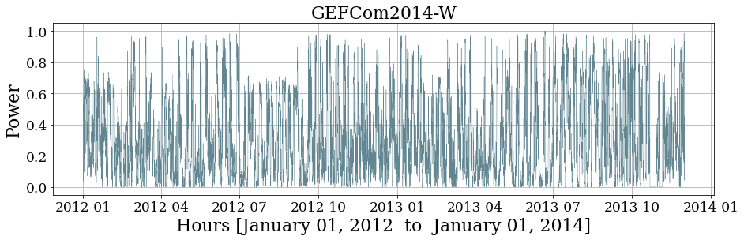

```python
Y_df, X_df, benchmark_df = GEFCom2014_W.load(directory='data', group='Task 15')

Y_df = Y_df[Y_df.unique_id==2]

ds = Y_df.ds.values
y_true = Y_df.y.values

x_plot = Y_df.ds.values
x_plot_min = pd.to_datetime(x_plot.min()).strftime('%B %d, %Y')
x_plot_max = pd.to_datetime(x_plot.max()).strftime('%B %d, %Y')
x_axis_str = f'Hours [{x_plot_min}  to  {x_plot_max}]'
y_axis_str = 'Power'

fig = plt.figure(figsize=(15, 4))
fig.tight_layout()
ax0 = plt.subplot2grid((1,1),(0, 0))
axs = [ax0]

axs[0].plot(ds, y_true, color='#628793', linewidth=0.4, label='true')
axs[0].tick_params(labelsize=FONTSIZE-5)
axs[0].set_xlabel(x_axis_str, fontsize=FONTSIZE)
axs[0].set_ylabel(y_axis_str, fontsize=FONTSIZE)
plt.title('GEFCom2014-W', fontsize=FONTSIZE)
plt.grid()
plt.show()
```

{% endraw %}

# GEFCom2014-S: Solar Power Generation Task Datasets

- Y: 3 target solar power series, for 3 different solar power plants.
- X: 12 weather variables associated to the solar power plants.
- Tasks: Fifteen one-month-ahead hourly solar power generation for 3 power platns.

> GEFcom2014-S meta information

{% raw %}

`class` `SolarTask1`[[source]](https://github.com/Nixtla/neuralforecast/tree/main/neuralforecast/data/datasets/gefcom2014.py#L809)

> `SolarTask1`(**`test_start`**:`str`=*`'04/01/2013'`*, **`test_end`**:`str`=*`'05/01/2013'`*)

SolarTask1(test_start: str = '04/01/2013', test_end: str = '05/01/2013')

{% endraw %} {% raw %}

`class` `SolarTask2`[[source]](https://github.com/Nixtla/neuralforecast/tree/main/neuralforecast/data/datasets/gefcom2014.py#L814)

> `SolarTask2`(**`test_start`**:`str`=*`'05/01/2013'`*, **`test_end`**:`str`=*`'06/01/2013'`*)

SolarTask2(test_start: str = '05/01/2013', test_end: str = '06/01/2013')

{% endraw %} {% raw %}

`class` `SolarTask3`[[source]](https://github.com/Nixtla/neuralforecast/tree/main/neuralforecast/data/datasets/gefcom2014.py#L819)

> `SolarTask3`(**`test_start`**:`str`=*`'06/01/2013'`*, **`test_end`**:`str`=*`'07/01/2013'`*)

SolarTask3(test_start: str = '06/01/2013', test_end: str = '07/01/2013')

{% endraw %} {% raw %}

`class` `SolarTask4`[[source]](https://github.com/Nixtla/neuralforecast/tree/main/neuralforecast/data/datasets/gefcom2014.py#L824)

> `SolarTask4`(**`test_start`**:`str`=*`'07/01/2013'`*, **`test_end`**:`str`=*`'08/01/2013'`*)

SolarTask4(test_start: str = '07/01/2013', test_end: str = '08/01/2013')

{% endraw %} {% raw %}

`class` `SolarTask5`[[source]](https://github.com/Nixtla/neuralforecast/tree/main/neuralforecast/data/datasets/gefcom2014.py#L829)

> `SolarTask5`(**`test_start`**:`str`=*`'08/01/2013'`*, **`test_end`**:`str`=*`'09/01/2013'`*)

SolarTask5(test_start: str = '08/01/2013', test_end: str = '09/01/2013')

{% endraw %} {% raw %}

`class` `SolarTask6`[[source]](https://github.com/Nixtla/neuralforecast/tree/main/neuralforecast/data/datasets/gefcom2014.py#L834)

> `SolarTask6`(**`test_start`**:`str`=*`'09/01/2013'`*, **`test_end`**:`str`=*`'10/01/2013'`*)

SolarTask6(test_start: str = '09/01/2013', test_end: str = '10/01/2013')

{% endraw %} {% raw %}

`class` `SolarTask7`[[source]](https://github.com/Nixtla/neuralforecast/tree/main/neuralforecast/data/datasets/gefcom2014.py#L839)

> `SolarTask7`(**`test_start`**:`str`=*`'10/01/2013'`*, **`test_end`**:`str`=*`'11/01/2013'`*)

SolarTask7(test_start: str = '10/01/2013', test_end: str = '11/01/2013')

{% endraw %} {% raw %}

`class` `SolarTask8`[[source]](https://github.com/Nixtla/neuralforecast/tree/main/neuralforecast/data/datasets/gefcom2014.py#L844)

> `SolarTask8`(**`test_start`**:`str`=*`'11/01/2013'`*, **`test_end`**:`str`=*`'12/01/2013'`*)

SolarTask8(test_start: str = '11/01/2013', test_end: str = '12/01/2013')

{% endraw %} {% raw %}

`class` `SolarTask9`[[source]](https://github.com/Nixtla/neuralforecast/tree/main/neuralforecast/data/datasets/gefcom2014.py#L849)

> `SolarTask9`(**`test_start`**:`str`=*`'12/01/2013'`*, **`test_end`**:`str`=*`'01/01/2014'`*)

SolarTask9(test_start: str = '12/01/2013', test_end: str = '01/01/2014')

{% endraw %} {% raw %}

`class` `SolarTask10`[[source]](https://github.com/Nixtla/neuralforecast/tree/main/neuralforecast/data/datasets/gefcom2014.py#L854)

> `SolarTask10`(**`test_start`**:`str`=*`'01/01/2014'`*, **`test_end`**:`str`=*`'02/01/2014'`*)

SolarTask10(test_start: str = '01/01/2014', test_end: str = '02/01/2014')

{% endraw %} {% raw %}

`class` `SolarTask11`[[source]](https://github.com/Nixtla/neuralforecast/tree/main/neuralforecast/data/datasets/gefcom2014.py#L859)

> `SolarTask11`(**`test_start`**:`str`=*`'02/01/2014'`*, **`test_end`**:`str`=*`'03/01/2014'`*)

SolarTask11(test_start: str = '02/01/2014', test_end: str = '03/01/2014')

{% endraw %} {% raw %}

`class` `SolarTask12`[[source]](https://github.com/Nixtla/neuralforecast/tree/main/neuralforecast/data/datasets/gefcom2014.py#L864)

> `SolarTask12`(**`test_start`**:`str`=*`'03/01/2014'`*, **`test_end`**:`str`=*`'04/01/2014'`*)

SolarTask12(test_start: str = '03/01/2014', test_end: str = '04/01/2014')

{% endraw %} {% raw %}

`class` `SolarTask13`[[source]](https://github.com/Nixtla/neuralforecast/tree/main/neuralforecast/data/datasets/gefcom2014.py#L869)

> `SolarTask13`(**`test_start`**:`str`=*`'04/01/2014'`*, **`test_end`**:`str`=*`'05/01/2014'`*)

SolarTask13(test_start: str = '04/01/2014', test_end: str = '05/01/2014')

{% endraw %} {% raw %}

`class` `SolarTask14`[[source]](https://github.com/Nixtla/neuralforecast/tree/main/neuralforecast/data/datasets/gefcom2014.py#L874)

> `SolarTask14`(**`test_start`**:`str`=*`'05/01/2014'`*, **`test_end`**:`str`=*`'06/01/2014'`*)

SolarTask14(test_start: str = '05/01/2014', test_end: str = '06/01/2014')

{% endraw %} {% raw %}

`class` `SolarTask15`[[source]](https://github.com/Nixtla/neuralforecast/tree/main/neuralforecast/data/datasets/gefcom2014.py#L879)

> `SolarTask15`(**`test_start`**:`str`=*`'06/01/2014'`*, **`test_end`**:`str`=*`'07/01/2014'`*)

SolarTask15(test_start: str = '06/01/2014', test_end: str = '07/01/2014')

{% endraw %} {% raw %}

{% endraw %} {% raw %}

`class` `GEFCom2014_S`[[source]](https://github.com/Nixtla/neuralforecast/tree/main/neuralforecast/data/datasets/gefcom2014.py#L893)

> `GEFCom2014_S`()

{% endraw %} {% raw %}

{% endraw %} {% raw %}

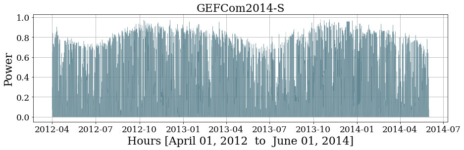

```python
Y_df, X_df, benchmark_df = GEFCom2014_S.load(directory='data', group='Task 15')

Y_df = Y_df[Y_df.unique_id==2]

ds = Y_df.ds.values
y_true = Y_df.y.values

x_plot = Y_df.ds.values
x_plot_min = pd.to_datetime(x_plot.min()).strftime('%B %d, %Y')
x_plot_max = pd.to_datetime(x_plot.max()).strftime('%B %d, %Y')
x_axis_str = f'Hours [{x_plot_min}  to  {x_plot_max}]'
y_axis_str = 'Power'

fig = plt.figure(figsize=(15, 4))
fig.tight_layout()
ax0 = plt.subplot2grid((1,1),(0, 0))
axs = [ax0]

axs[0].plot(ds, y_true, color='#628793', linewidth=0.4, label='true')
axs[0].tick_params(labelsize=FONTSIZE-5)
axs[0].set_xlabel(x_axis_str, fontsize=FONTSIZE)
axs[0].set_ylabel(y_axis_str, fontsize=FONTSIZE)
plt.title('GEFCom2014-S', fontsize=FONTSIZE)
plt.grid()
plt.show()
```

{% endraw %}